# day1_2

**Updates on genomic selection**

Day 1: Fundamentals of genomic selection

**Saulo Chaves**

Assistant Professor

Data Science for Plant Breeding Lab

Piracicaba, September 1<sup>st</sup>

[figure not shown]

# Practical session

## The dataset

[figure not shown]

[G2F](https://www.genomes2fields.org/home/)

## Phenotypic data

```r
library(tidyverse)

dat = readRDS("../Data/G2F.RDS")
str(dat)
```

```
'data.frame':   85949 obs. of  7 variables:
 $ gen      : chr  "B37/C103" "B37/H95" "B73/MO17" "B73/PHG35" ...
 $ year     : int  2014 2014 2014 2014 2014 2014 2014 2014 2014 2014 ...
 $ loc      : chr  "GAH1" "GAH1" "GAH1" "GAH1" ...
 $ env      : chr  "GAH1_2014" "GAH1_2014" "GAH1_2014" "GAH1_2014" ...
 $ blue     : num  4.69 5.98 6.29 9.73 8.05 ...
 $ std.error: num  0.828 0.828 0.828 0.828 0.828 ...
 $ wt       : num  1.91 1.91 1.91 1.91 1.91 ...
```

## Phenotypic data

**Código**

```r
ggplot(data = as.data.frame(table(dat$gen, dat$env)),
       aes(x = Var2, y = Var1, fill = as.factor(Freq))) +
  geom_tile(aes(alpha = as.factor(Freq))) +
  theme_minimal() +
  theme(axis.text = element_blank(), legend.title = element_blank(),
        legend.position = 'top') +
  scale_fill_manual(values = c('#b2bc63','#10342d'), labels = c("Abscent", "Present")) +
  scale_alpha_manual(values = c(.6, 1), labels = c("Abscent", "Present")) +
  labs(x = "Environment (Year-Location combination)", y = "Hybrid")
```

[figure not shown]

## Phenotypic data

```r
dat = dat[which(dat$env == "WIH3_2023"),]
str(dat)
```

```
'data.frame':   413 obs. of  7 variables:
 $ gen      : chr  "2369/LH123HT" "B14A/OH43" "B37/H95" "B73/MO17" ...
 $ year     : int  2023 2023 2023 2023 2023 2023 2023 2023 2023 2023 ...
 $ loc      : chr  "WIH3" "WIH3" "WIH3" "WIH3" ...
 $ env      : chr  "WIH3_2023" "WIH3_2023" "WIH3_2023" "WIH3_2023" ...
 $ blue     : num  11.3 11.9 13.9 16.1 16.6 ...
 $ std.error: num  0.707 0.707 0.707 0.707 0.707 ...
 $ wt       : num  2 2 2 2 2 ...
```

## Genomic data

Package `vcfR` (Knaus & Grünwald, 2016)

```r
library(vcfR)
vcf = read.vcfR(file = "../Data/markers.vcf")
```

[output not shown]

## Genomic data

```r
geno = extract.gt(x = vcf)
geno = geno[-grep(',', vcf@fix[,'ALT']),] # Remove multi-allelic mrks
vcf@fix = vcf@fix[-grep(',',vcf@fix[,'ALT']),]
geno = gsub('/', "", geno)
geno[1:5,1:5]
```

```
           01CSI6/LH287 01DIB2/LH287 01DIB2/PHP02 2369/DK3IIH6 2369/LH123HT
S1_1007742 "01"         "11"         "11"         "01"         "01"
S1_1020677 "00"         "00"         "01"         "00"         "01"
S1_2018002 "00"         "00"         "01"         "01"         "00"
S1_2101934 "00"         "00"         NA           "00"         "01"
S1_2275970 "00"         "00"         "00"         "00"         "01"
```

## Genomic data

```r
# Binding reference and alternative allele to marker matrix
geno = cbind(geno, vcf@fix[,c('REF', 'ALT')])
geno = apply(geno, 1, function(x){
  y = gsub('0', x['REF'], x)
  z = gsub('1', y['ALT'], y)
  z
})
geno[1:5,1:5]
```

```
             S1_1007742 S1_1020677 S1_2018002 S1_2101934 S1_2275970
01CSI6/LH287 "TC"       "GG"       "TT"       "TT"       "AA"
01DIB2/LH287 "CC"       "GG"       "TT"       "TT"       "AA"
01DIB2/PHP02 "CC"       "GA"       "TC"       NA         "AA"
2369/DK3IIH6 "TC"       "GG"       "TC"       "TT"       "AA"
2369/LH123HT "TC"       "GA"       "TT"       "TC"       "AC"
```

## Genomic data

```r
geno = geno[-which(rownames(geno) %in% c('REF', 'ALT')), ]
geno[grep('CA', geno)] = 'AC'
geno[grep('GA', geno)] = 'AG'
geno[grep('TA', geno)] = 'AT'
geno[grep('GC', geno)] = 'CG'
geno[grep('TC', geno)] = 'CT'
geno[grep('TG', geno)] = 'GT'
geno[1:5,1:5]
```

```
             S1_1007742 S1_1020677 S1_2018002 S1_2101934 S1_2275970
01CSI6/LH287 "CT"       "GG"       "TT"       "TT"       "AA"
01DIB2/LH287 "CC"       "GG"       "TT"       "TT"       "AA"
01DIB2/PHP02 "CC"       "AG"       "CT"       NA         "AA"
2369/DK3IIH6 "CT"       "GG"       "CT"       "TT"       "AA"
2369/LH123HT "CT"       "AG"       "TT"       "CT"       "AC"
```

## Genomic data

**Filtering step**

```r
Freqsnps = apply(geno, 2, table)
Freqsnps = do.call(rbind, lapply(Freqsnps, data.frame)) |>
  rownames_to_column("mrk") |> mutate(mrk = gsub('\\..*', '', mrk))
head(Freqsnps)
```

```
         mrk Var1 Freq
1 S1_1007742   CC 2968
2 S1_1007742   CT 2566
3 S1_1007742   TT  346
4 S1_1020677   AA  564
5 S1_1020677   AG 2619
6 S1_1020677   GG 2638
```

## Genomic data

**Filtering step**

```r
Freqall = apply(geno, 2, function(x){
  aux = as.data.frame(table(do.call(c, strsplit(x = x, split = ''))))
  return(aux)
})
Freqall = do.call(rbind, Freqall) |>
  rownames_to_column("mrk") |> mutate(mrk = gsub('\\..*', '', mrk))
head(Freqall)
```

```
         mrk Var1 Freq
1 S1_1007742    C 8502
2 S1_1007742    T 3258
3 S1_1020677    A 3747
4 S1_1020677    G 7895
5 S1_2018002    C 3166
6 S1_2018002    T 8584
```

```r
Freqmis = apply(geno, 2, function(x) mean(is.na(x)))
head(Freqmis)
```

```
 S1_1007742  S1_1020677  S1_2018002  S1_2101934  S1_2275970  S1_2800964
0.003220885 0.013222580 0.004068486 0.331073063 0.014578742 0.005763689
```

## Genomic data

Removing markers with $\geq$ 5% of missing data

```r
geno = geno[,-which(Freqmis >= 0.05)]
vcf@fix = vcf@fix[-which(Freqmis >= 0.05),]
dim(geno)
```

```
[1] 5899 2146
```

```r
any(is.na(geno))
```

```
[1] TRUE
```

Impute missing data with the mode

```r
for (i in colnames(geno)) {
  if(!any(is.na(geno[,i]))) next else{
    geno[which(is.na(geno[,i])),i] = as.character(
      Freqsnps[which(Freqsnps$mrk == i), ][which.max(Freqsnps[which(Freqsnps$mrk == i), ][,'Freq']), "Var1"]
      )
  }
  rm(i)
}
any(is.na(geno))
```

```
[1] FALSE
```

## Genomic data

Removing markers with MAF $\leq$ 5%

```r
Freqall$Fper = Freqall$Freq / (nrow(geno) * 2)
geno = geno[,-which(Freqall$Fper <= 0.05)]
dim(geno)
```

```
[1] 5899 2105
```

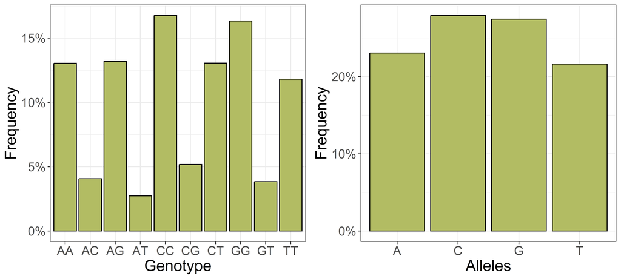

## Genomic data

**Re-codification according to the dosage of the reference allele**

```r
geno.code = matrix(
  nrow = nrow(geno),
  ncol = ncol(geno),
  dimnames = list(rownames(geno), colnames(geno))
)
for (i in colnames(geno)) {
  x = geno[, i]
  geno.code[, i] = nchar(gsub(paste0("[^", vcf@fix[which(vcf@fix[, "ID"] == i),
                                                   'REF'], "]"), "", x))
}
geno.code[1:5,1:5]
```

```
             S1_1007742 S1_1020677 S1_2018002 S1_2275970 S1_2800964
01CSI6/LH287          1          2          2          2          2
01DIB2/LH287          0          2          2          2          1
01DIB2/PHP02          0          1          1          2          0
2369/DK3IIH6          1          2          1          2          1
2369/LH123HT          1          1          2          1          2
```

```r
# saveRDS(geno.code, file = "Data/mrk_filtered.RDS")
```

## Genomic data

**Principal component plot**

**Código**

```r
pca = prcomp(geno.code)
pc.df = rbind(
  as.data.frame(pca$rotation) |>
    rownames_to_column("ID") |>
    mutate(comp = "load"),
  as.data.frame(pca$x) |>
    mutate(ID = paste0("ind", 1:nrow(pca$x)),
           comp = "score")
)
ggplot(dat = subset(pc.df, subset = comp == 'score'), aes(x = PC1, y = PC2)) +
  geom_point(size = 3, alpha = .5, colour = "#b2bc63") +
  geom_vline(xintercept = 0, linetype = "dashed") +
  geom_hline(yintercept = 0, linetype = 'dashed') +
  scale_x_continuous(limits = range(pca$x[,1:2])) +
  scale_y_continuous(limits = range(pca$x[,1:2])) +
  coord_fixed() +
  theme_minimal() +
  theme(text= element_text(size = 18)) +
  labs(x = paste0("PC1 (", round(pca$sdev[1]^2/sum(pca$sdev^2)*100,2), "%)"),
       y= paste0("PC2 (", round(pca$sdev[2]^2/sum(pca$sdev^2)*100,2), "%)"))
```

[figure not shown]

## Ridge Regression

$$\boldsymbol y = \boldsymbol 1 \mu + \boldsymbol W \boldsymbol u + \boldsymbol \varepsilon$$

- $\boldsymbol W \to$ matrix of markers recoded to numeric scale
- $\boldsymbol u \to$ vector of marker effects

RR-BLUP assumes that all markers effects are normally distributed and have identical variance:

$$\boldsymbol u \sim \mathcal N \left(\boldsymbol 0, \sigma^2_u \boldsymbol I \right)$$

## Ridge Regression

$$\boldsymbol u \sim \mathcal N \left(\boldsymbol 0, \sigma^2_u \boldsymbol I \right)$$

[figure not shown]

## Ridge Regression

Solution via mixed model equation

$$\begin{bmatrix}
\boldsymbol{1}^\prime \boldsymbol 1 & \boldsymbol 1^\prime \boldsymbol W \\
\boldsymbol W^\prime \boldsymbol 1 & \left(\boldsymbol W^\prime \boldsymbol W + \lambda \boldsymbol{I} \right)
\end{bmatrix} \begin{bmatrix}
\boldsymbol \mu \\
\boldsymbol u
\end{bmatrix} =
\begin{bmatrix}
\boldsymbol 1^\prime \boldsymbol y \\
\boldsymbol W^\prime \boldsymbol y
\end{bmatrix}$$

**Shrinkage factor**: Shrinks the marker effects towards zero

$$\lambda = \frac{\sigma^2_\varepsilon}{\sigma^2_u}$$

## Ridge Regression

**Assure compatibility between phenotypic and genomic data**

```r
all(dat$gen %in% rownames(geno.code))
```

```
[1] FALSE
```

```r
which(!dat$gen %in% rownames(geno.code))
```

```
[1] 338 370
```

```r
dat = dat[which(dat$gen %in% rownames(geno.code)),]
all(dat$gen %in% rownames(geno.code))
```

```
[1] TRUE
```

## Ridge Regression

**Assure compatibility between genomic and phenotypic data**

```r
all(rownames(geno.code) %in% dat$gen)
```

```
[1] FALSE
```

```r
which(!rownames(geno.code) %in% dat$gen)
```

[output not shown]

[output cut: 377 more lines]

```r
geno.code = geno.code[which(rownames(geno.code) %in% dat$gen),]
all(rownames(geno.code) %in% dat$gen)
```

```
[1] TRUE
```

Don’t forget to check the order of both datasets

```r
all(rownames(geno.code) == dat$gen)
```

```
[1] TRUE
```

## Ridge Regression

Package `rrBLUP` (Endelman, 2011)

```r
library(rrBLUP)
geno_rr = geno.code - 1  # Recoding the marker matrix
geno_rr[1:5,1:5]
```

```
             S1_1007742 S1_1020677 S1_2018002 S1_2275970 S1_2800964
2369/LH123HT          0          0          1          0          1
B14A/OH43             1          1          1          1          1
B37/H95              -1          0          0          0          0
B73/MO17              0          1          1          1          0
B73/PHN82             0          0          0          1          0
```

```r
mod = mixed.solve(y = dat$blue, Z = geno_rr)
```

## Ridge Regression

```r
blup_rr = mod$u
```

**Código**

```r
data.frame(blup_rr) |>
  rownames_to_column(var = "Marker") |>
  rename(BLUP = 'blup_rr') |>
  ggplot(aes(x = Marker, y = BLUP))+
  geom_point(alpha = .6, colour = "#10342d", size = 2)+
  theme_minimal() +
  theme(axis.text.x = element_blank(),
        axis.ticks.x=element_blank(),
        text = element_text(size = 18))
```

[figure not shown]

## Ridge Regression

$$\hat{\boldsymbol g} = \boldsymbol W \hat{\boldsymbol u}$$

```r
GEBV = geno_rr %*% blup_rr
```

**Código**

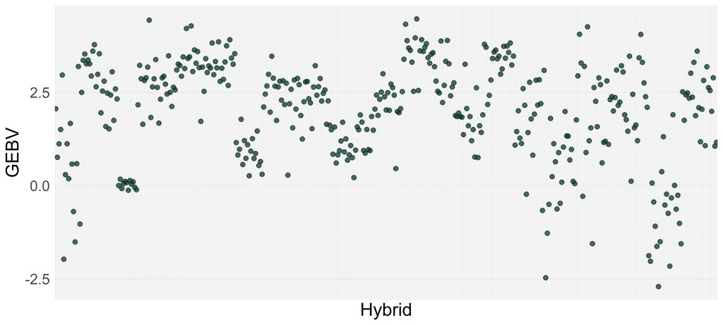

```r
as.data.frame(GEBV) |> rownames_to_column(var = "gen") |>
  rename(GEBV = V1) |>
  ggplot(aes(x = gen, y = GEBV))+
  geom_point(alpha = .75, colour = "#10342d", size = 2) +
  theme_minimal() +
  theme(axis.text.x = element_blank(), axis.ticks.x=element_blank(),
        text = element_text(size = 18))+
  labs(x = "Hybrid", y = "GEBV")
```

## Ridge Regression

**Model parameters**

$$\hat{\sigma}^2_g = \sigma^2_u \times p$$

```r
Vg = mod$Vu * ncol(geno_rr); Vg
```

```
[1] 12.80676
```

```r
Ve = mod$Ve; Ve
```

```
[1] 4.854941
```

```r
mu = mod$beta; mu
```

```
[1] 11.81567
```

```r
geno_her = Vg/(Vg + Ve); geno_her
```

```
[1] 0.7251148
```

```r
cor(dat$blue, GEBV, use = "complete.obs")
```

```
         [,1]
[1,] 0.769064
```

## BayesB

$$\boldsymbol y = \boldsymbol 1 \mu + \boldsymbol W \boldsymbol u + \boldsymbol \varepsilon$$

- $\boldsymbol W \to$ matrix of markers recoded to numeric scale
- $\boldsymbol u \to$ vector of marker effects

BayesB assumes that some markers are unimportant for the trait variation, hence have no effect. Furthermore, it relaxes the assumption that all markers have the same variance:

$$u_i \sim \mathcal N \left( 0, \sigma^2_{u_i} \right)$$

## BayesB

- Prior for the variances: scaled inverse $\chi^2 \left[\sigma^2_{u_i} \sim \chi^{-2}\left(\nu\right)\right]$
- Prior for the importance parameter (say, $I$): $I \sim \operatorname{Bernoulli}(\Pi)$

$$\hat{g}_i = I_1 \times w_{1i} \times \hat u_1 + I_2 \times w_{2i} \times \hat u_2 + \dots + I_p \times w_{pi} \times \hat u_p$$

- $I_j \to$ 1 or 0

## BayesB

Package `BGLR` (Pérez & Campos, 2014)

```r
X_centred = scale(geno.code, center = TRUE, scale = FALSE)
ETA = list(list(X = X_centred, model = "BayesB")) ## This will determine the model
BayesB = BGLR(y = dat$blue, ETA = ETA, nIter = 70000, burnIn = 20000,
              thin = 10, verbose = FALSE, saveAt = "complete_")
```

In [Bayesian models](https://github.com/storopoli/Estatistica-Bayesiana), you should mind the number of iterations, the burn-in phase and the thinning. The more, the better, but it will take longer for your model to run.

[figure not shown]

[Prof. Jose Storopoli](https://storopoli.github.io/Estatistica-Bayesiana/5-MCMC.html)

## BayesB

**Convergence check through model diagnostics**: Package `coda` (Plummer et al., 2006)

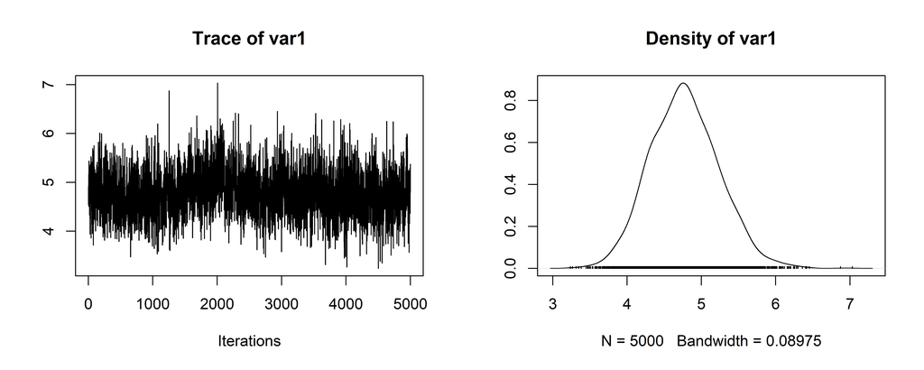

```r
library(coda)
varE = read.table("../complete_varE.dat")[,1]
varE_chain = mcmc(varE[2001:length(varE)]) # burnIn/thin + 1
plot(varE_chain)
```

## BayesB

**Effective sample size**: The number of independent samples from posterior distributions. The higher, the better. If low, increase `nIter` or `thin`

```r
effectiveSize(varE_chain)
```

```
    var1
709.6943
```

**Geweke convergence test**: evaluates if the MCMC chain reached a stationary state. It should be between -1.96 and 1.96. If not, increase `burnIn`

```r
geweke.diag(varE_chain)
```

```
Fraction in 1st window = 0.1
Fraction in 2nd window = 0.5

 var1
1.637
```

## BayesB

```r
GEBV_bb = data.frame(Hybrid = dat$gen, GEBV = BayesB$yHat)
cor(GEBV, GEBV_bb$GEBV)
```

```
          [,1]
[1,] 0.9984064
```

**Código**

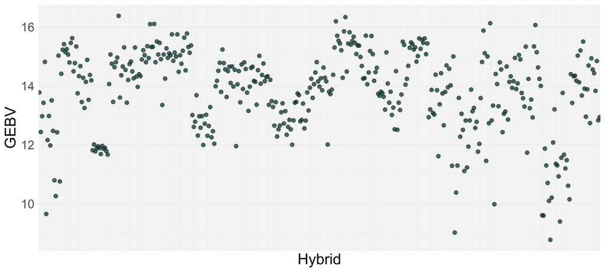

```r
ggplot(data = GEBV_bb, aes(x = Hybrid, y = GEBV))+
  geom_point(alpha = .75, colour = "#10342d", size = 2) +
  theme_minimal() +
  theme(axis.text.x = element_blank(), axis.ticks.x=element_blank(),
        text = element_text(size = 18))+
  labs(x = "Hybrid", y = "GEBV")
```

## BayesB

**Model parameters**

```r
BayesB$ETA[[1]]$b  # mrk effects
```

[output not shown]

[output cut: 787 more lines]

[output not shown]

```r
BayesB$ETA[[1]]$d # Probability of inclusion: Frequency that the SNP had effect different than 0
```

[output not shown]

[output cut: 196 more lines]

```r
BayesB$varE # Residual variance
```

```
[1] 4.774841
```

```r
var(BayesB$yHat)  # Genetic variance
```

```
[1] 1.939678
```

## BayesB

**Código**

```r
df_bayesB = data.frame(
  Marker = colnames(X_centred),
  Effect = BayesB$ETA[[1]]$b,
  PPI = BayesB$ETA[[1]]$d
)

ggplot(df_bayesB, aes(x = 1:nrow(df_bayesB), y = PPI)) +
  geom_point(aes(color = PPI > 0.5), alpha = 0.75, size = 1.7) +
  scale_color_manual(values = c("grey", "#10342d")) +
  labs(x = "Markers", y = "Posterior probability of inclusion") +
  theme_minimal() +
  theme(legend.position = 'top', text = element_text(size = 18))
```

[figure not shown]

## Cross-validation

**Define cross-validation parameters**

```r
nfolds = 5
nrept = 5
seed = 8

cvdata = list()
for (j in 1:nrept) {
  set.seed(seed*j)
  cvdata[[j]] = dat[,c('gen', 'blue')]
  cvdata[[j]]$set = NA
  for (i in cvdata[[j]]$gen) {
    cvdata[[j]][cvdata[[j]]$gen == i,'set'] = sample(
      1:nfolds,
      size = 1
    )
  }
}
```

## Cross-validation

Run RRBLUP in cross-validation

```r
cv_rr = lapply(cvdata, function(x){
  res.list = list()
  for (i in unique(x$set)) {

    yNA = x$blue
    yNA[x$set == i] = NA

    mod_cv = mixed.solve(y = yNA, Z = geno_rr)

    pred = c(mod_cv$beta) + (geno_rr %*% mod_cv$u)

    res.list[[i]] = cbind(
      x[x$set == i,],
      yhat = pred[x$set == i,]
    )
  }
  res.list
})
cv_rr = lapply(cv_rr, function(x) do.call(rbind, x))
```

## Cross-validation

Run BayesB in cross-validation

```r
cv_bb = lapply(cvdata, function(x){
  res.list = list()
  for (i in unique(x$set)) {

    yNA = x$blue
    yNA[x$set == i] = NA

    mod_cv = BGLR(y = yNA, ETA = ETA, nIter = 8000, burnIn = 1000,
                  thin = 10, verbose = FALSE)
    unlink("*.dat")

    res.list[[i]] = data.frame(gen = x$gen, yhat = mod_cv$yHat) |>
      left_join(x, by = "gen") |> filter(set == i)
  }
  res.list
})
cv_bb = lapply(cv_bb, function(x) do.call(rbind, x))
```

## Cross-validation

Model evaluation

```r
pa_rr = lapply(cv_rr, function(x) cor(x$blue, x$yhat, use = 'complete.obs'))
mspe_rr = lapply(cv_rr, function(x) sqrt(mean((x$blue - x$yhat)^2, na.rm = T)))

pa_bb = lapply(cv_bb, function(x) cor(x$blue, x$yhat, use = 'complete.obs'))
mspe_bb = lapply(cv_bb, function(x) sqrt(mean((x$blue - x$yhat)^2, na.rm = T)))
```

## Cross-validation

Model evaluation

**Código**

```r
aux = data.frame(
  model = rep(c("RRBLUP", "BayesB"), each = nfolds*2),
  value = c(do.call(c, pa_rr), do.call(c, mspe_rr),
            do.call(c, pa_bb), do.call(c, mspe_bb)),
  param = c(rep(c("PA", "RMSPE"), each = 5), rep(c("PA", "RMSPE"), each = 5))
)

ggplot(data = aux, aes(x = model, y = value)) +
  facet_wrap(~param, scales = "free_y") +
  geom_boxplot(fill = "#b2bc63") +
  theme_bw() +
  theme(text = element_text(size = 18))+
  labs(x = "Model") +
  theme(axis.title.y = element_blank())
```

[figure not shown]

## References

Endelman, J. B. (2011). Ridge regression and other kernels for genomic selection with R package rrBLUP. *Plant Genome*, *4*, 250–255.

Knaus, B. J., & Grünwald, N. J. (2016). VcfR: an R package to manipulate and visualize VCF format data. *BioRxiv*. https://dx.doi.org/10.1101/041277

Lima, D. C., Washburn, J. D., Varela, J. I., Chen, Q., Gage, J. L., Romay, M. C., Holland, J., Ertl, D., Lopez-Cruz, M., Aguate, F. M., Campos, G. de los, Kaeppler, S., Beissinger, T., Bohn, M., Buckler, E., Edwards, J., Flint-Garcia, S., Gore, M. A., Hirsch, C. N., … Leon, N. de. (2023). Genomes to Fields 2022 Maize genotype by Environment Prediction Competition. *BMC Research Notes*, *16*(1), 148. https://doi.org/10.1186/s13104-023-06421-z

Pérez, P., & Campos, G. de los. (2014). Genome-wide regression and prediction with the BGLR statistical package. *Genetics*, *198*(2), 483–495. https://doi.org/10.1534/genetics.114.164442

Plummer, M., Best, N., Cowles, K., & Vines, K. (2006). CODA: Convergence Diagnosis and Output Analysis for MCMC. *R News*, *6*(1), 7–11. https://journal.r-project.org/archive/